# TENNIS TOURNAMENTS RESULTS FROM 2019

Myriam Ragni  
21 February 2020

### INTRODUCTION

The purpose of this assignment was to create a Shiny application and to produce a pitch presentation.  
My Shiny application presents a table view of the tennis match results per Men/Women tournament which took place in 2019.

- The Shiny application code is available here: http://github.com/RAGNIMY1/DevelopingDataProducts
- The application is hosted here: http://myriamragni.shinyapps.io/tennistournaments/
- Guidance to the usage of the application can be found in the 'About' tab of the application.

### DATA SOURCE

Data has been extracted from http://www.tennis-data.co.uk/alldata.php.  
My Shiny application is based on the ATP Men's and WTA Women's Tour data for the 2019 season.  
*Extract of the Men data set for the 'French Open' Tournament:*

```r
dfMen <- read.xlsx("./TennisTournamentsMen2019.xlsx",sheet = 1, colNames=TRUE)
dfMenExtract <- dfMen %>%
        select(Tournament, Round, Winner, Loser, W1, L1, W2, L2, W3, L3) %>%
        filter(Tournament=="French Open",Round=="Quarterfinals"|Round=="Semifinals")
kable(x=dfMenExtract,booktabs=T,align='ccc') %>% kable_styling(font_size = 14)
```

| Tournament | Round | Winner | Loser | W1 | L1 | W2 | L2 | W3 | L3 |
| --- | --- | --- | --- | --- | --- | --- | --- | --- | --- |
| French Open | Quarterfinals | Federer R. | Wawrinka S. | 7 | 6 | 4 | 6 | 7 | 6 |
| French Open | Quarterfinals | Nadal R. | Nishikori K. | 6 | 1 | 6 | 1 | 6 | 3 |
| French Open | Quarterfinals | Djokovic N. | Zverev A. | 7 | 5 | 6 | 2 | 6 | 2 |
| French Open | Quarterfinals | Thiem D. | Khachanov K. | 6 | 2 | 6 | 4 | 6 | 2 |
| French Open | Semifinals | Nadal R. | Federer R. | 6 | 3 | 6 | 4 | 6 | 2 |
| French Open | Semifinals | Thiem D. | Djokovic N. | 6 | 2 | 3 | 6 | 7 | 5 |

### SHINY APPLICATION

The Main Panel is subdivided into 4 tabs:

**General Information:** gives information to the serie/tier of the tournament, the location and the court surface  
**Tournament Results:** provides a table with the match results for the selected tournament (screenshot below)  
**About:** provides a description of the application  
**References:** contains the link to the source code.

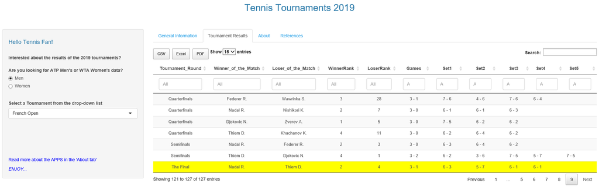

### CODE EXTRACT server.R

The following is an excerpt of the server logic.  
It shows the function used to generate a HTML table view of the tournament's results.

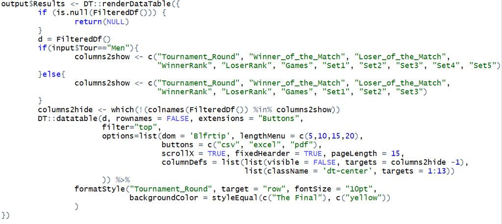